# Kaggle Covid19: Causal Analysis with DAGs

Florian Endel

2025-01-28

# Causal Analysis with DAGs

In this section, we explore the causal relationships between different factors and COVID-19 outcomes. We use Directed Acyclic Graphs (DAGs) to formalize our causal assumptions and guide our analysis.

## DAG Specification and Initial Analysis

First, we create a DAG representing our hypothesized causal relationships. This graph shows how different medical conditions and demographic factors might influence COVID-19 mortality.

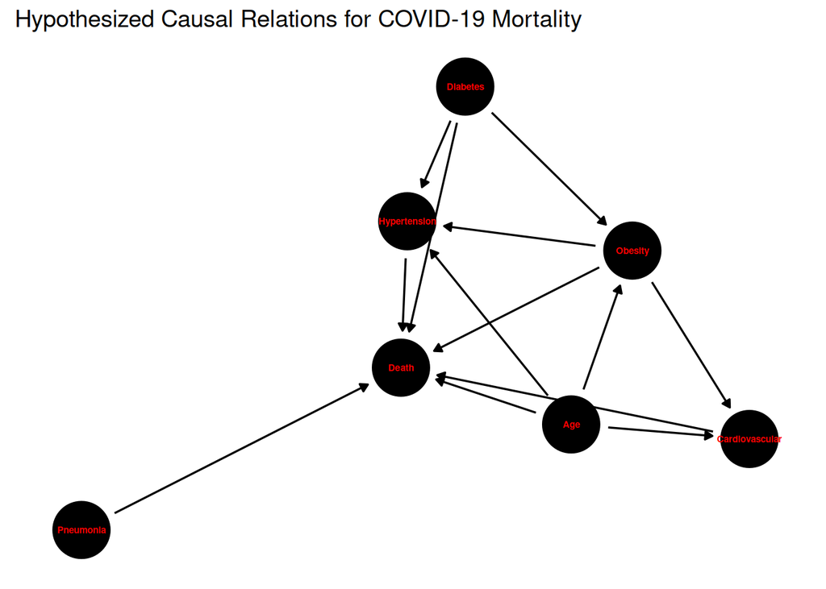

The DAG reveals several pathways through which obesity may affect mortality: - Direct effect: Obesity -> Death - Via cardiovascular system: Obesity -> Cardiovascular -> Death - Via blood pressure: Obesity -> Hypertension -> Death This multiple-pathway structure explains why controlling for mediators (like hypertension) is expected to reduce the total estimated effect.

## Identifying Causal Paths and Adjustment Sets

Next, we examine the paths between key variables and identify proper adjustment sets for causal estimation.

All Paths from Obesity to Death

| Path | Open (d-connected) |
| --- | --- |
| Obesity -> Cardiovascular -> Death | TRUE |
| Obesity -> Cardiovascular <- Age -> Death | FALSE |
| Obesity -> Cardiovascular <- Age -> Hypertension -> Death | FALSE |
| Obesity -> Cardiovascular <- Age -> Hypertension <- Diabetes -> Death | FALSE |
| Obesity -> Death | TRUE |
| Obesity -> Hypertension -> Death | TRUE |
| Obesity -> Hypertension <- Age -> Cardiovascular -> Death | FALSE |
| Obesity -> Hypertension <- Age -> Death | FALSE |
| Obesity -> Hypertension <- Diabetes -> Death | FALSE |
| Obesity <- Age -> Cardiovascular -> Death | TRUE |
| Obesity <- Age -> Death | TRUE |
| Obesity <- Age -> Hypertension -> Death | TRUE |
| Obesity <- Age -> Hypertension <- Diabetes -> Death | FALSE |
| Obesity <- Diabetes -> Death | TRUE |
| Obesity <- Diabetes -> Hypertension -> Death | TRUE |
| Obesity <- Diabetes -> Hypertension <- Age -> Cardiovascular -> Death | FALSE |
| Obesity <- Diabetes -> Hypertension <- Age -> Death | FALSE |

The table shows the paths from Obesity to Death, including whether the path is open (d-connected)[^1]

Minimal Adjustment Sets for Estimating Obesity’s Effect on Death

| Adjustment Set |
| --- |
| Age, Diabetes |

The DAG analysis identifies that we need to adjust for **Age** and **Diabetes** to estimate the causal effect of obesity on mortality. This means:

1. Age and diabetes are confounders - they affect both obesity and death risk independently
2. Without adjusting for these variables, our estimate of obesity’s effect on death would be biased
3. After adjusting for age and diabetes, any remaining association between obesity and death can be interpreted more causally

This suggests that in our statistical analyses, we should always control for age and diabetes when estimating the effect of obesity on COVID-19 mortality. Other variables like hypertension and cardiovascular disease are potential mediators (they lie on the causal pathway between obesity and death) and should not be adjusted for if we want to estimate the total causal effect of obesity.

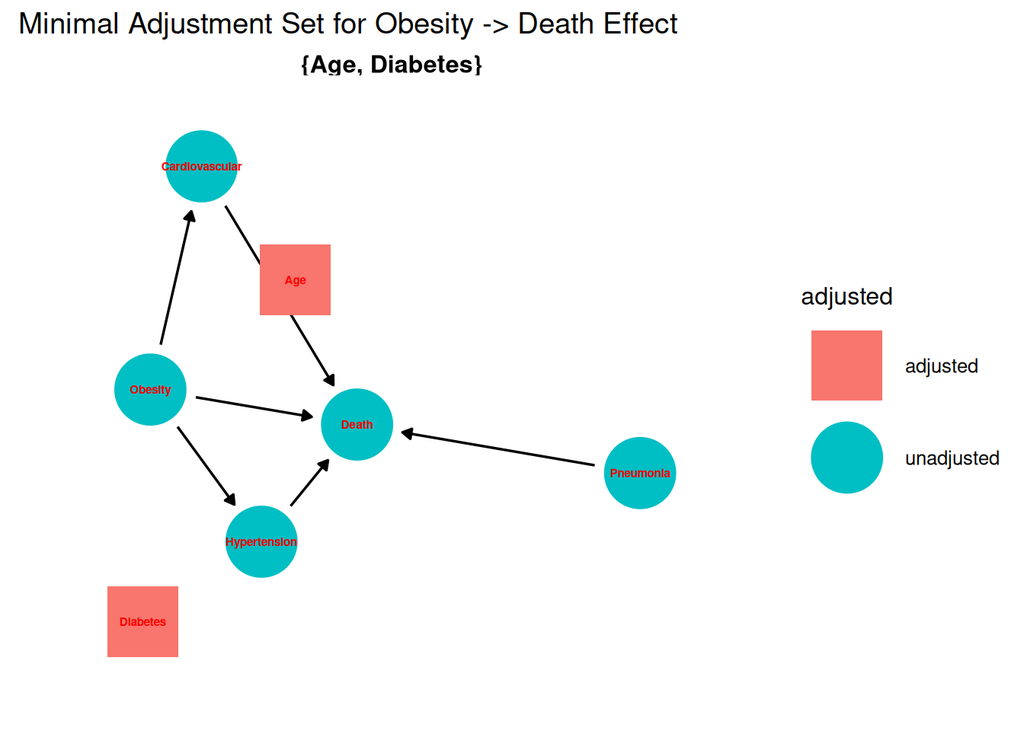

## Testing DAG Implications with Data

Now we’ll test whether our data is consistent with the causal assumptions encoded in our DAG.

Tests of Conditional Independence

| Variable | Estimate | P-value |
| --- | --- | --- |
| Obesity | 0.384 | 0 |
| Hypertension | 0.471 | 0 |

The test results show significant associations (p < 0.001) between:

1. Obesity and Death, even after adjusting for Age and Diabetes, supporting a causal relationship
2. Hypertension and Death, even after adjusting for Age and Obesity, suggesting an independent effect

These results are consistent with our DAG’s structure.

## Estimating Causal Effects

Based on the adjustment sets identified by our DAG, we estimate the causal effect of obesity on mortality.

Estimated Causal Effect of Obesity on Mortality

[output not shown]

## Interpretation

The DAG-based analysis shows that obesity has a significant causal effect on COVID-19 mortality. The properly adjusted model (controlling for age and diabetes) indicates that obesity increases the odds of death by 46.75% (OR = 1.47, 95% CI: 1.44-1.5).

The DAG analysis reveals several important insights:

## Limitations

This causal analysis has several limitations:

- The DAG represents our assumptions about causal relationships but cannot prove causality.
- We assume no unmeasured confounding.
- The relationships are likely more complex than shown in our simplified DAG.
- Missing data and measurement error could bias our estimates.
[^1]: d-connected: A path in a causal graph is considered d-connected (or “open”) if it transmits association (correlation). This means that the variables in the path are statistically related unless they are blocked by a collider. We are not adjusting for colliders in the given example.